```python
import numpy as np
import matplotlib.pyplot as plt
import csv
from sklearn.linear_model import LogisticRegression
from sklearn.neighbors import KNeighborsClassifier
from matplotlib.colors import ListedColormap
from sklearn.discriminant_analysis import QuadraticDiscriminantAnalysis
from sklearn.discriminant_analysis import LinearDiscriminantAnalysis
from sklearn.svm import SVC
from sklearn.preprocessing import StandardScaler
```

```python
# for some sets of input parameters, SVM will be slow to converge.  We will terminate early.
# This code will suppress warnings.
import warnings
from sklearn.exceptions import ConvergenceWarning
warnings.simplefilter("ignore", ConvergenceWarning)
```

# 1 Ch4.7

You don't need to show the first few steps shown here:

$$Prob(Y= \text{Yes} | X = 4) = \frac{ Prob(Y= \text{Yes} , X = 4) }{ Prob(X = 4) }$$$$Prob(Y= \text{Yes} | X = 4) = \frac{ Prob( X = 4 | Y= \text{Yes} ) Prob(Y= \text{Yes})}{ Prob(X = 4) }$$$$Prob(Y= \text{Yes} | X = 4) = \frac{ Prob( X = 4 | Y= \text{Yes} ) Prob(Y= \text{Yes})}{ Prob( X = 4 | Y= \text{Yes} ) Prob(Y= \text{Yes}) + Prob( X = 4 | Y= \text{No} ) Prob(Y= \text{No}) }$$

From the information given, $$Prob(Y= \text{Yes}) = 0.8 \qquad Prob(Y= \text{No}) = 0.2$$ and $$ Prob( X = 4 | Y= \text{Yes} ) = \frac{1}{\sqrt{2 \pi \sigma_{ \text{Yes}}^2} } e^{ -(4-\mu_{\text{Yes}})^2 / (2\sigma_{ \text{Yes}}^2) } $$ Since $$\sigma_{ \text{Yes}} = \sigma_{ \text{No}}$$ we can cancel the fractions, leaving $$Prob(Y= \text{Yes} | X = 4) = \frac{ 0.8 e^{ -(4-10)^2 / (2* 36) } }{ 0.8 e^{ -(4-10)^2 / (2* 36) } + 0.2 e^{ -(4-0)^2 / (2* 36) } } = \frac{0.485}{0.485 + 0.160} = 0.752$$

Although not necessary, you might observe that the probability is almost the prior. This is not by mistake. The distributions overlap heavily due to the large variance and (relative to the variance) close means. If you plot the distributions (below) you will see they are close.

```python
print(0.8 * np.exp( -(4-10)**2 / (2* 36) ))
print(0.2 * np.exp( -(4-0)**2 / (2* 36) ))
print(0.485/(0.485 + 0.160))
```

```
0.4852245277701068
0.16014748058336162
0.751937984496124
```

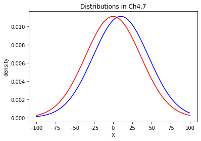

```python
import numpy as np
import matplotlib.pyplot as plt

X = np.linspace(-100,100,1000)
mu = 10
var=36**2
Yes = 1/np.sqrt(2*np.pi*var)*np.exp( -(X-mu)**2/2/var  )
mu = 0
No = 1/np.sqrt(2*np.pi*var)*np.exp( -(X-mu)**2/2/var  )
plt.figure()
plt.plot(X,Yes,'blue')
plt.plot(X,No,'red')
plt.xlabel('X')
plt.ylabel('density')
plt.title('Distributions in Ch4.7')
# print(Yes)
```

# 2

Part (a): From the book, we can see (4.20) is the equation characterizing the $x_1$ and $x_2$ values that are on the boundary. Since each covariance matrix is the identity matrix, $$\Sigma= \begin{bmatrix} 1 & 0\\ 0 & 1 \end{bmatrix}$$ each inverse is also the identity matrix $$\Sigma^{-1}= \begin{bmatrix} 1 & 0\\ 0 & 1 \end{bmatrix}$$

Plugging into the formula (4.20), let's first evaluate the left hand side (just for $k=+1$)

$$\delta_{+1}\left(\begin{bmatrix} x_1\\ x_2 \end{bmatrix}\right) = \begin{bmatrix} x_1 & x_2 \end{bmatrix} \begin{bmatrix} 1 & 0\\ 0 & 1 \end{bmatrix} \begin{bmatrix} -1\\-1 \end{bmatrix} - \frac{1}{2} \begin{bmatrix} -1&-1 \end{bmatrix} \begin{bmatrix} 1 & 0\\ 0 & 1 \end{bmatrix} \begin{bmatrix} -1\\-1 \end{bmatrix} $$$$\delta_{+1}\left(\begin{bmatrix} x_1\\ x_2 \end{bmatrix}\right) = \begin{bmatrix} x_1 & x_2 \end{bmatrix} \begin{bmatrix} -1\\-1 \end{bmatrix} - \frac{1}{2} \begin{bmatrix} -1&-1 \end{bmatrix} \begin{bmatrix} -1\\-1 \end{bmatrix} $$

which simplifies to

$$\delta_{+1}\left(\begin{bmatrix} x_1\\ x_2 \end{bmatrix}\right) = -x_1-x_2 -1 $$

Using similar work, we can get $$\delta_{+2}\left(\begin{bmatrix} x_1\\ x_2 \end{bmatrix}\right) = x_1+x_2 -1 $$

So the boundary will be where $$-x_1-x_2 -1 = x_1+x_2 -1 $$ or equivalently $$x_1= -x_2$$ (this is a diagonal line going down and right)

Part (b). With almost the same work as before, we get $$\delta_{+3}\left(\begin{bmatrix} x_1\\ x_2 \end{bmatrix}\right) = -x_1+x_2 -1 $$

So the boundary will be where $$-x_1-x_2 -1 =-x_1+x_2 -1$$ or equivalently $$0= x_2,$$ the horizontal axis

Part (c). The boundary will be where $$x_1+x_2 -1 =-x_1+x_2 -1$$ or equivalently $$0= x_1,$$ the vertical axis

Part (d): (To-do -- make a plot, showing means as dots, boundaries, and label)

```
(-2, 2)
```

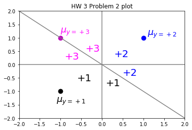

```python
X1 = np.linspace(-10,10,100)

plt.plot([-3,3],[0,0],'grey')
plt.plot([0,0],[-3,3],'grey')
plt.plot([-3,3],[3,-3],'grey')

plt.scatter([-1], [-1],  color='k',s=80)
plt.scatter([1], [1],  color='b',s=80)
plt.scatter([-1], [1],  color='m',s=80)

plt.text(1.1,1.1,r'$\mu_{y=+2}$',{'color': 'blue', 'fontsize': 18})
plt.text(-1.1,-1.4,r'$\mu_{y=+1}$',{'color': 'black', 'fontsize': 18})
plt.text(-1,1.2,r'$\mu_{y=+3}$',{'color': 'magenta', 'fontsize': 18})

plt.text(0.3,0.3,'+2',{'color': 'blue', 'fontsize': 20})
plt.text(0.5,-0.4,'+2',{'color': 'blue', 'fontsize': 20})
plt.text(-0.9,0.2,'+3',{'color': 'magenta', 'fontsize': 20})
plt.text(-0.4,0.5,'+3',{'color': 'magenta', 'fontsize': 20})
plt.text(-0.6,-0.6,'+1',{'color': 'black', 'fontsize': 20})
plt.text(0.1,-0.8,'+1',{'color': 'black', 'fontsize': 20})


plt.title('HW 3 Problem 2 plot')
plt.xlim([-2,2])
plt.ylim([-2,2])
```

Part (e): Since the covariance matrices are equal, QDA and LDA would be the same. LDA and QDA only differ when the covariance matrices are different.

Part (f): Naive Bayes would assume the features $x_1$ and $x_2$ are independent, which for jointly Gaussian variables means the covariance matrix is diagonal. For this problem, the covariance matrix is already diagonal, so nothing would change.

# 3 (9.1)

```
(-10, 10)
```

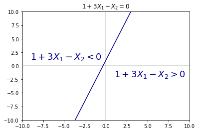

```python
X1 = np.linspace(-10,10,100)
X2 = 1+3*X1
plt.plot([-10,10],[0,0],'lightgrey')
plt.plot([0,0],[-10,10],'lightgrey')
plt.plot(X1,X2,'darkblue')
plt.title('$1+3X_1-X_2=0$')
plt.text(1,-2,r'$1+3X_1-X_2>0$',{'color': 'darkblue', 'fontsize': 18})
plt.text(-9,1.2,r'$1+3X_1-X_2<0$',{'color': 'darkblue', 'fontsize': 18})
plt.xlim([-10,10])
plt.ylim([-10,10])
```

Part (b): (for clarity we put on a separate plot) $$-2+X_1+2X_2>0$$ points are those on the opposite side of the origin (since $-2+0+2*0<0$), so above and to the right

```
(-10, 10)
```

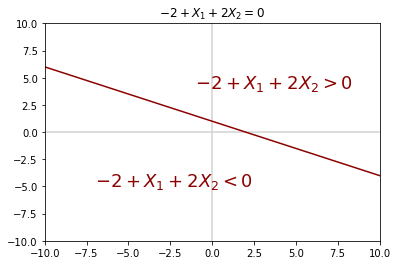

```python
X1 = np.linspace(-10,10,100)

plt.plot([-10,10],[0,0],'lightgrey')
plt.plot([0,0],[-10,10],'lightgrey')

# X2 = 1+3*X1
# plt.plot(X1,X2,'cyan')

X2 = 1-0.5*X1
plt.plot(X1,X2,'darkred')
plt.title('$-2+X_1+2X_2=0$')

plt.text(-1,4,r'$-2+X_1+2X_2>0$',{'color': 'darkred', 'fontsize': 18})
plt.text(-7,-5,r'$-2+X_1+2X_2<0$',{'color': 'darkred', 'fontsize': 18})

plt.xlim([-10,10])
plt.ylim([-10,10])
```

# 4 (Ch 9.2)

(a) There are a few ways to figure this out. One is to look for points, such as setting $(1+X_1)^2=0$, giving $X_1 =-1$, and solving $(2-X_2)^2=4$, which yields points $(-1,0)$ and $(-1,4)$. Repeat with $(2-X_2)^2=0$ to get $(-3,2)$ and $(1,2)$. From their you can sketch the curve, or try a few more points.

Alternatively, you can try to solve for $X_2$, with $$ (2-X_2)^2 = 4- (1+X_1)^2, $$ which means $$ (2-X_2) =\pm \sqrt{ 4- (1+X_1)^2 },$$ implying $$X_2 = 2 \pm \sqrt{ 4- (1+X_1)^2 }.$$ Then plug in values for $X_1$ and calculate. Note that we need $4- (1+X_1)^2\geq 0$, giving $4\geq (1+X_1)^2 $ and then $2\geq |1+X_1| $ so $X_1 \in [-3,1]$.

```
(-5, 5)
```

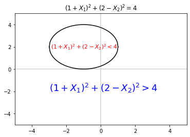

```python
X1 = np.linspace(-3,1,100)

plt.plot([-10,10],[0,0],'lightgrey')
plt.plot([0,0],[-10,10],'lightgrey')

X2 = 2+np.sqrt(4 - (1+X1)**2)
plt.plot(X1,X2,'black')

X2 = 2-np.sqrt(4 - (1+X1)**2)
plt.plot(X1,X2,'black')

plt.text(-2.9,1.8,r'$(1+X_1)^2+(2-X_2)^2<4$',{'color': 'red', 'fontsize': 11})
plt.text(-3,-2,r'$(1+X_1)^2+(2-X_2)^2>4$',{'color': 'blue', 'fontsize': 18})

plt.title('$ (1+X_1)^2+(2-X_2)^2=4$')
plt.xlim([-5,5])
plt.ylim([-5,5])
```

(b) This boundary has two sides, though it is inside and outside. Pick any point, such as the origin. $$ (1+0)^2+(2-0)^2>4,$$ so the points on the same side as the origin, the outside, satisfy $>4$. The points inside satisfy $< 4$.

(c) We just saw that the origin satisfies $>4$, so the blue class.

$$ (1-1)^2+(2-1)^2 =1 < 4,$$

so $(-1,1)$ is in the red class.

$$ (1+2)^2+(2-2)^2 =9> 4,$$

so $(2,2)$ is in the blue class

$$ (1+3)^2+(2-8)^2 > 4,$$

so $(2,2)$ is in the blue class

(d) If we unravel the formula, we get $$(1+X_1)^2+(2-X_2)^2=4$$

Treating $X_1^2$ and $X_2^2$ as two extra variables, then we have a multiple linear equation in four variables.

# 5

# 5.A Scatterplots

```python
# load training set
ytrain = []
Xtrain = []
with open('HW3train.csv', 'r') as csvfile:
    reader = csv.reader(csvfile, delimiter=',',lineterminator='\n')
    for row in reader:
#         print(row)
        if len(row)==3:
            ytrain.append( int(row[0]) )
            Xtrain.append( [float(row[1]) , float(row[2]) ])

Xtrain = np.array(Xtrain)
ytrain = np.array(ytrain)

#Verify values loaded correctly
# print(ytrain)
# print(Xtrain)
```

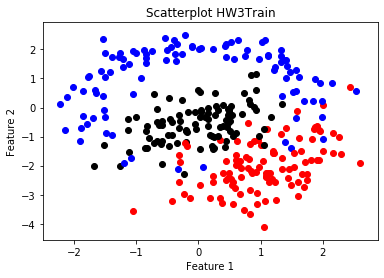

```python
for x,y in zip(Xtrain, ytrain):
#     print(x1,x2,y)
    if y==1:
        col = 'blue'
    if y==2:
        col = 'red'
    if y==3:
        col = 'black'
    plt.scatter(x[0], x[1],  color=col)

plt.title('Scatterplot HW3Train')
# plt.scatter(x0test, np.zeros((10)),  color='red')
plt.xlabel('Feature 1')
plt.ylabel('Feature 2')
# plt.savefig('HW3trainscatter.png',dpi=300,bbox_inches='tight')
```

```python
# load testing set
ytest = []
Xtest = []
with open('HW3test.csv', 'r') as csvfile:
    reader = csv.reader(csvfile, delimiter=',',lineterminator='\n')
    for row in reader:
#         print(row)
        if len(row)==3:
            ytest.append( int(row[0]) )
            Xtest.append( [float(row[1]) , float(row[2]) ])

Xtest = np.array(Xtest)
ytest = np.array(ytest)

#Verify values loaded correctly
# print(ytest)
# print(Xtest)
```

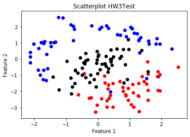

```python
for x,y in zip(Xtest, ytest):
#     print(x1,x2,y)
    if y==1:
        col = 'blue'
    if y==2:
        col = 'red'
    if y==3:
        col = 'black'
    plt.scatter(x[0], x[1],  color=col)

plt.title('Scatterplot HW3Test')
# plt.scatter(x0test, np.zeros((10)),  color='red')
plt.xlabel('Feature 1')
plt.ylabel('Feature 2')
# plt.savefig('HW3trainscatter.png',dpi=300,bbox_inches='tight')
```

To visualize the region for each class $$y\in\{+1,+2,+3\},$$ we will use a meshgrid

```python
h = .02  # step size in the mesh (increase if code runs too slow)

# Plot the decision boundary. For that, we will assign a color to each
# point in the mesh [x_min, x_max]x[y_min, y_max].
x1_min, x1_max = Xtrain[:, 0].min() - 1, Xtrain[:, 0].max() + 1
x2_min, x2_max = Xtrain[:, 1].min() - 1, Xtrain[:, 1].max() + 1
x1mesh, x2mesh = np.meshgrid(np.arange(x1_min, x1_max, h),
                         np.arange(x2_min, x2_max, h))
```

# 5 B (1)

```python
# Create color maps
cmap_light = ListedColormap(['lightblue', 'lightcoral', 'grey'])
cmap_bold = ListedColormap(['blue', 'red', 'black'])
```

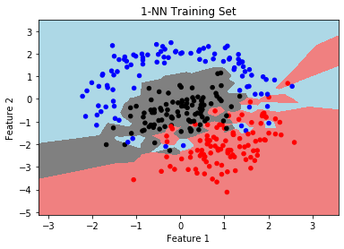

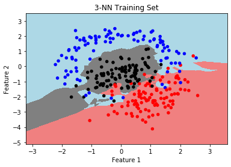

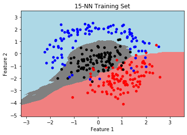

```python
for n_neighbors in [1,3,15]:
    # we create an instance of Neighbours Classifier and fit the data.

    clf = KNeighborsClassifier(n_neighbors, weights='uniform')
    clf.fit(Xtrain, ytrain)

    Z = clf.predict(np.c_[x1mesh.ravel(), x2mesh.ravel()])

    # Put the result into a color plot
    Z = Z.reshape(x1mesh.shape)

    # Plot the training points with the mesh
    plt.figure()
    plt.pcolormesh(x1mesh, x2mesh, Z, cmap=cmap_light)
    ytrain_colors = [y-1 for y in ytrain]
    plt.scatter(Xtrain[:, 0], Xtrain[:, 1], c=ytrain_colors, cmap=cmap_bold, s=20)
    plt.xlim(x1_min, x1_max)
    plt.ylim(x2_min, x2_max)
    plt.title('%i-NN Training Set' % (n_neighbors))
    plt.xlabel('Feature 1')
    plt.ylabel('Feature 2')

plt.show()
```

# 5 B (2)

We see that the general regions of blue, grey, and red are the same for each $k$ plotted here. But for small $k$, there are more disconnected regions, little islands of red, grey, and blue surrounded by another color. As $k$ increases, the regions become more contiguous, so with $k=15$, except for a little sliver of blue, we see a single blue region, a single grey region, and a single red region. Also, the boundaries, while still having some jaggedness, are overall smoother than with small $k$.

You did not need to, but here are plots with testing points as well

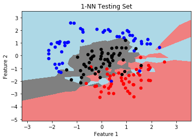

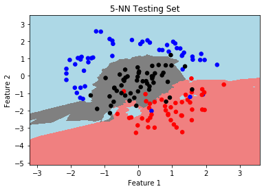

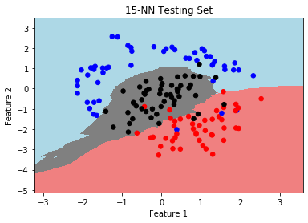

```python
for n_neighbors in [1,5,15]:
    # we create an instance of Neighbours Classifier and fit the data.
    clf = KNeighborsClassifier(n_neighbors, weights='uniform')
    clf.fit(Xtrain, ytrain)

    Z = clf.predict(np.c_[x1mesh.ravel(), x2mesh.ravel()])

    # Put the result into a color plot
    Z = Z.reshape(x1mesh.shape)


    # Plot the testing points with the mesh
    ypred = clf.predict(Xtest)
    plt.figure()
    plt.pcolormesh(x1mesh, x2mesh, Z, cmap=cmap_light)
    ytest_colors = [y-1 for y in ytest]
    plt.scatter(Xtest[:, 0], Xtest[:, 1], c=ytest_colors, cmap=cmap_bold, s=30)
    plt.xlim(x1_min, x1_max)
    plt.ylim(x2_min, x2_max)
    plt.title('%i-NN Testing Set' % (n_neighbors))
    plt.xlabel('Feature 1')
    plt.ylabel('Feature 2')



plt.show()
```

# 5 B (3) - (5)

```
Working on k=1
	The training accuracy is 1.0000
	The testing accuracy is 0.8133
Working on k=2
	The training accuracy is 0.9433
	The testing accuracy is 0.8400
Working on k=3
	The training accuracy is 0.9333
	The testing accuracy is 0.8533
Working on k=4
	The training accuracy is 0.9233
	The testing accuracy is 0.8533
Working on k=5
	The training accuracy is 0.9300
	The testing accuracy is 0.8667
Working on k=6
	The training accuracy is 0.9167
	The testing accuracy is 0.8800
Working on k=7
	The training accuracy is 0.9100
	The testing accuracy is 0.8933
Working on k=8
	The training accuracy is 0.9200
	The testing accuracy is 0.8933
Working on k=9
	The training accuracy is 0.9167
	The testing accuracy is 0.9000
Working on k=10
	The training accuracy is 0.9167
	The testing accuracy is 0.9067
Working on k=11
	The training accuracy is 0.9067
	The testing accuracy is 0.9067
Working on k=12
	The training accuracy is 0.9100
	The testing accuracy is 0.9000
Working on k=13
	The training accuracy is 0.9100
	The testing accuracy is 0.9067
Working on k=14
```

[output cut: 34 more lines]

```
	The testing accuracy is 0.8867
Working on k=26
	The training accuracy is 0.9067
	The testing accuracy is 0.8933
Working on k=27
	The training accuracy is 0.9067
	The testing accuracy is 0.8867
Working on k=28
	The training accuracy is 0.9067
	The testing accuracy is 0.8867
Working on k=29
	The training accuracy is 0.9033
	The testing accuracy is 0.8800
The best $k$=15
The plots are included above
```

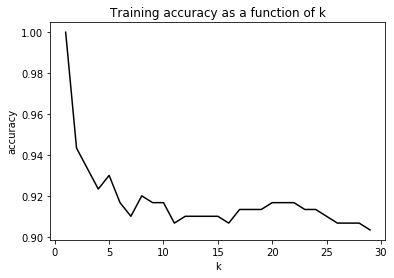

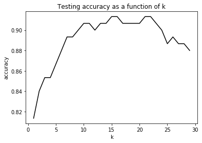

```python
# Now make plots of Training Accuracy and plots of Testing Accuracy for KNN for k in {1,3,5,7,9,11,13,15}

trainacc = []
testacc = []
for k in range(1,30,1):
    print('Working on k=%i'%(k))
    neigh = KNeighborsClassifier(n_neighbors=k,weights='uniform',algorithm='auto')
    neigh.fit(Xtrain, ytrain)
    trainacc.append( neigh.score(Xtrain,ytrain) )
    testacc.append( neigh.score(Xtest,ytest) )
    print('\tThe training accuracy is %.4f'%(neigh.score(Xtrain,ytrain)))
    print('\tThe testing accuracy is %.4f'%(neigh.score(Xtest,ytest)))


plt.figure()

plt.plot(range(1,30,1),trainacc,color='black')
plt.title('Training accuracy as a function of k')
plt.xlabel('k')
plt.ylabel('accuracy')

plt.figure()

plt.plot(range(1,30,1),testacc,color='black')
plt.title('Testing accuracy as a function of k')
plt.xlabel('k')
plt.ylabel('accuracy')

idx = testacc.index(max(testacc))
print('The best $k$=%i'%(idx+1))
print('The plots are included above')
```

If we see multiple $k$ that achieve the same testing accuracy, you can pick any of them to use for (6) and (7)

# 5 C LDA

```python
h = .01  # step size in the mesh (shrink for better pictures)

# Plot the decision boundary. For that, we will assign a color to each
# point in the mesh [x_min, x_max]x[y_min, y_max].
x1_min, x1_max = Xtrain[:, 0].min() - 1, Xtrain[:, 0].max() + 1
x2_min, x2_max = Xtrain[:, 1].min() - 1, Xtrain[:, 1].max() + 1
x1mesh, x2mesh = np.meshgrid(np.arange(x1_min, x1_max, h),
                         np.arange(x2_min, x2_max, h))
```

# 5 C (1)

```python
clf = LinearDiscriminantAnalysis(solver='svd', shrinkage=None, priors=None)
clf.fit(Xtrain, ytrain)

LDAtrainacc = clf.score(Xtrain, ytrain)
LDAtestacc = clf.score(Xtest, ytest)

print('Training Accuracy for LDA: %.2f'%(LDAtrainacc))
print('Testing Accuracy for LDA: %.2f'%(LDAtestacc))
```

```
Training Accuracy for LDA: 0.83
Testing Accuracy for LDA: 0.81
```

# 5 C (2)-(3)

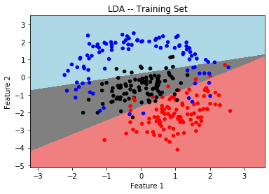

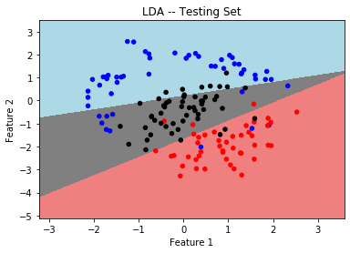

```python
clf = LinearDiscriminantAnalysis(solver='svd', shrinkage=None, priors=None)
clf.fit(Xtrain, ytrain)

Z = clf.predict(np.c_[x1mesh.ravel(), x2mesh.ravel()])

# Put the result into a color plot
Z = Z.reshape(x1mesh.shape)

# Plot the training points with the mesh
plt.figure()
plt.pcolormesh(x1mesh, x2mesh, Z, cmap=cmap_light)
ytrain_colors = [y-1 for y in ytrain]
plt.scatter(Xtrain[:, 0], Xtrain[:, 1], c=ytrain_colors, cmap=cmap_bold, s=20)
plt.xlim(x1_min, x1_max)
plt.ylim(x2_min, x2_max)
plt.title('LDA -- Training Set')
plt.xlabel('Feature 1')
plt.ylabel('Feature 2')

# Plot the testing points with the mesh
plt.figure()
plt.pcolormesh(x1mesh, x2mesh, Z, cmap=cmap_light)
ytest_colors = [y-1 for y in ytest]
plt.scatter(Xtest[:, 0], Xtest[:, 1], c=ytest_colors, cmap=cmap_bold, s=20)
plt.xlim(x1_min, x1_max)
plt.ylim(x2_min, x2_max)
plt.title('LDA -- Testing Set')
plt.xlabel('Feature 1')
plt.ylabel('Feature 2')
```

# 5 D. QDA

```python
clf = QuadraticDiscriminantAnalysis(priors=None, reg_param=0.0)
clf.fit(Xtrain, ytrain)

QDAtrainacc = clf.score(Xtrain, ytrain)
QDAtestacc = clf.score(Xtest, ytest)

print('Training Accuracy for QDA: %.2f'%(QDAtrainacc))
print('Testing Accuracy for QDA: %.2f'%(QDAtestacc))
```

```
Training Accuracy for QDA: 0.90
Testing Accuracy for QDA: 0.87
```

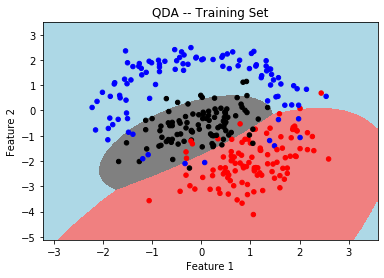

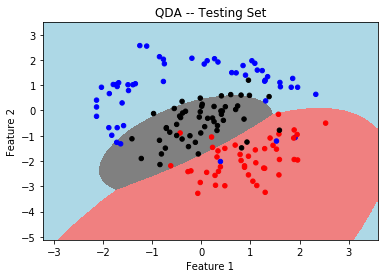

```python
#Now plot both training set and testing set

Z = clf.predict(np.c_[x1mesh.ravel(), x2mesh.ravel()])

# Put the result into a color plot
Z = Z.reshape(x1mesh.shape)

# Plot the training points with the mesh
plt.figure()
plt.pcolormesh(x1mesh, x2mesh, Z, cmap=cmap_light)
ytrain_colors = [y-1 for y in ytrain]
plt.scatter(Xtrain[:, 0], Xtrain[:, 1], c=ytrain_colors, cmap=cmap_bold, s=20)
plt.xlim(x1_min, x1_max)
plt.ylim(x2_min, x2_max)
plt.title('QDA -- Training Set')
plt.xlabel('Feature 1')
plt.ylabel('Feature 2')

# Plot the testing points with the mesh
plt.figure()
plt.pcolormesh(x1mesh, x2mesh, Z, cmap=cmap_light)
ytest_colors = [y-1 for y in ytest]
plt.scatter(Xtest[:, 0], Xtest[:, 1], c=ytest_colors, cmap=cmap_bold, s=20)
plt.xlim(x1_min, x1_max)
plt.ylim(x2_min, x2_max)
plt.title('QDA -- Testing Set')
plt.xlabel('Feature 1')
plt.ylabel('Feature 2')
```

# 5 E

LDA is distinct, as it has linear boundaries, and we see a triangle shaped region for the black points, with blue above and red below. Considering how simple the boundaries are (and the incorrect assumptions that each class is Gaussian and they all have the same covariance matrix), it actually doesn't do a terrible job.

QDA visually does a decent job, as it has a grey region that is almost an ellipse inside the blue points. Because of the estimated variances (black smallest, then red, then blue) we notice blue region wraps around the the red (in the bottom right corner).

The $15$-NN regions and the QDA are not that different visually though the NN method has better testing accuracy.

# 5 F (1)-(4) SVMs with Polynomial Kernels

```
Degree 1
Accuracy [train, test] -- C - gamma
Best C and best gamma =  5.62e+00 - 1.00e+00
Training Accuracy: 0.85
Testing Accuracty: 0.85


Degree 2
Accuracy [train, test] -- C - gamma
Best C and best gamma =  1.00e-01 - 1.00e+00
Training Accuracy: 0.92
Testing Accuracty: 0.91


Degree 3
Accuracy [train, test] -- C - gamma
Best C and best gamma =  3.16e-01 - 1.00e+00
Training Accuracy: 0.92
Testing Accuracty: 0.92


Degree 4
Accuracy [train, test] -- C - gamma
Best C and best gamma =  1.00e-02 - 1.00e+00
Training Accuracy: 0.91
Testing Accuracty: 0.91
```

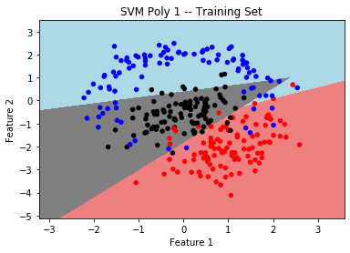

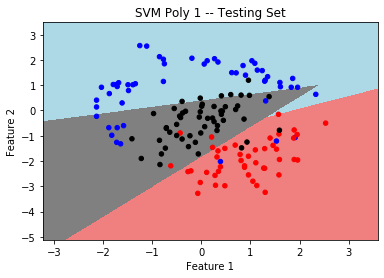

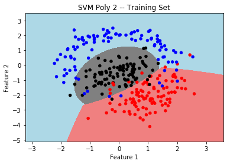

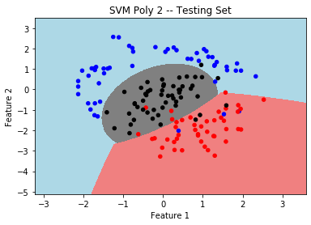

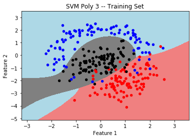

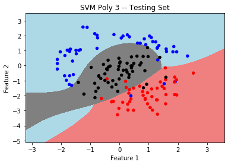

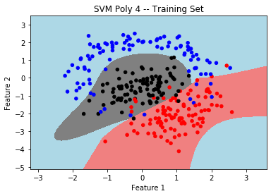

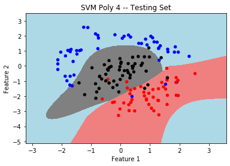

```python
degree = 1
max_iter=1000

Cvals = np.logspace(-4,2,25,base=10)
gamma_vals = [1] #np.logspace(-2,2,25,base=10)



for degree in [1,2,3,4]:
    bestc = 0
    bestgamma = 0
    besttrainacc = 0
    besttestacc = 0
    print('\n\nDegree %i'%(degree))
    print('Accuracy [train, test] -- C - gamma')
    for c in Cvals:
        for gamma in gamma_vals:

            clf = SVC(C=c, kernel='poly', degree=degree, gamma=gamma, coef0=1.0, shrinking=True, probability=False,max_iter=max_iter)

            clf.fit(Xtrain, ytrain)

            trainacc = clf.score(Xtrain, ytrain)
            testacc = clf.score(Xtest, ytest)

#             print('[%.4f, %.4f] -- %.2e - %.2ef'%( trainacc, testacc, c, gamma ))

            if testacc > besttestacc:
                besttestacc = testacc
                besttrainacc = trainacc
                bestgamma = gamma
                bestc = c



    clf = SVC(C=bestc, kernel='poly', degree=degree, gamma=bestgamma, coef0=1.0, shrinking=True, probability=False)

    clf.fit(Xtrain, ytrain)

    print('Best C and best gamma =  %.2e - %.2e'%(  bestc, bestgamma ))
    print('Training Accuracy: %.2f'%(besttestacc))
    print('Testing Accuracty: %.2f'%(besttrainacc))

    Z = clf.predict(np.c_[x1mesh.ravel(), x2mesh.ravel()])

    # Put the result into a color plot
    Z = Z.reshape(x1mesh.shape)

    # Plot the training points with the mesh
    plt.figure()
    plt.pcolormesh(x1mesh, x2mesh, Z, cmap=cmap_light)
    ytrain_colors = [y-1 for y in ytrain]
    plt.scatter(Xtrain[:, 0], Xtrain[:, 1], c=ytrain_colors, cmap=cmap_bold, s=20)
    plt.xlim(x1_min, x1_max)
    plt.ylim(x2_min, x2_max)
    plt.title('SVM Poly %i -- Training Set'%(degree))
    plt.xlabel('Feature 1')
    plt.ylabel('Feature 2')

    # Plot the testing points with the mesh
    plt.figure()
    plt.pcolormesh(x1mesh, x2mesh, Z, cmap=cmap_light)
    ytest_colors = [y-1 for y in ytest]
    plt.scatter(Xtest[:, 0], Xtest[:, 1], c=ytest_colors, cmap=cmap_bold, s=20)
    plt.xlim(x1_min, x1_max)
    plt.ylim(x2_min, x2_max)
    plt.title('SVM Poly %i -- Testing Set'%(degree))
    plt.xlabel('Feature 1')
    plt.ylabel('Feature 2')
```

# 5 G (1)-(4) SVMs with RBF kernel

```
Accuracy [train, test] -- C - gamma
Best C and best gamma =  1.78e-01 - 2.15e-01
Training Accuracy: 0.93
Testing Accuracty: 0.91
```

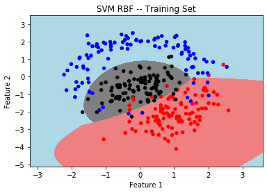

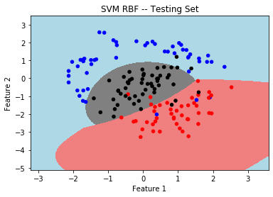

```python
max_iter=1000

Cvals = np.logspace(-4,2,25,base=10)
gamma_vals = np.logspace(-2,2,25,base=10)

bestc = 0
bestgamma = 0
besttrainacc = 0
besttestacc = 0

print('Accuracy [train, test] -- C - gamma')
for c in Cvals:
    for gamma in gamma_vals:

        clf = SVC(C=c, kernel='rbf', gamma=gamma,shrinking=True, probability=False,max_iter=max_iter)

        clf.fit(Xtrain, ytrain)

        trainacc = clf.score(Xtrain, ytrain)
        testacc = clf.score(Xtest, ytest)

#             print('[%.4f, %.4f] -- %.2e - %.2ef'%( trainacc, testacc, c, gamma ))

        if testacc > besttestacc:
            besttestacc = testacc
            besttrainacc = trainacc
            bestgamma = gamma
            bestc = c

print('Best C and best gamma =  %.2e - %.2e'%(  bestc, bestgamma ))
print('Training Accuracy: %.2f'%(besttestacc))
print('Testing Accuracty: %.2f'%(besttrainacc))

clf = SVC(C=bestc, kernel='rbf', gamma=bestgamma, shrinking=True, probability=False)

clf.fit(Xtrain, ytrain)

Z = clf.predict(np.c_[x1mesh.ravel(), x2mesh.ravel()])

# Put the result into a color plot
Z = Z.reshape(x1mesh.shape)

# Plot the training points with the mesh
plt.figure()
plt.pcolormesh(x1mesh, x2mesh, Z, cmap=cmap_light)
ytrain_colors = [y-1 for y in ytrain]
plt.scatter(Xtrain[:, 0], Xtrain[:, 1], c=ytrain_colors, cmap=cmap_bold, s=20)
plt.xlim(x1_min, x1_max)
plt.ylim(x2_min, x2_max)
plt.title('SVM RBF -- Training Set')
plt.xlabel('Feature 1')
plt.ylabel('Feature 2')

# Plot the testing points with the mesh
plt.figure()
plt.pcolormesh(x1mesh, x2mesh, Z, cmap=cmap_light)
ytest_colors = [y-1 for y in ytest]
plt.scatter(Xtest[:, 0], Xtest[:, 1], c=ytest_colors, cmap=cmap_bold, s=20)
plt.xlim(x1_min, x1_max)
plt.ylim(x2_min, x2_max)
plt.title('SVM RBF -- Testing Set')
plt.xlabel('Feature 1')
plt.ylabel('Feature 2')
```

# 5 H

SVM with degree 1 polynomial kernel (linear kernel) also has linear decision boundaries, similar to LDA, though does not have distributional assumptions (of normality) build in, so the shapes are different and performance better.

Likewise, the degree 2 polynomial kernel SVM is learning quadratic boundaries, giving similar regions to QDA, but with different position and changes to the shape since the SVM does not rely on normality assumptions of the features.

Interestingly, the RBF kernel also learns boundaries that are close to quadratic, although in general that is not the case. The main difference between those latter 3 methods is the regions further from the points (eg at the corners of the pictures). But close to the points they generally look similar.

The higher-order polynomial kernels generally agree with the QDA and RBF kernel around the points, but then on the edges of the figure have distinct shapes. The degree 3 kernel shares some resemblence with the $15$-NN classifier.

# 5 I

Supposing the data was randomly generated, so the samples we see should be representative of future samples (drawn from the same distribution), then $3$-NN, SVM with polynomial degree 2 kernel, or SVM with RBF kernel might come closest to capturing the shapes of the underlying regions, especially the 'arms' of the blue points surrounding the black region. Though $3$-NN has some islands and jagged boundaries that are probably not representative of underlying distribution, and the grey region of the RBF kernel seems to not quite be visually aligned with the black points.

(It is fine to have different opinions than this, provided there is some reasoning)